# Time Series Homework #4

Luke Schwenke

2023-07-15

# Question 1

Combine the data from the 16 files into a single dataset and plot it. Describe the dataset characteristics.

[output not shown]

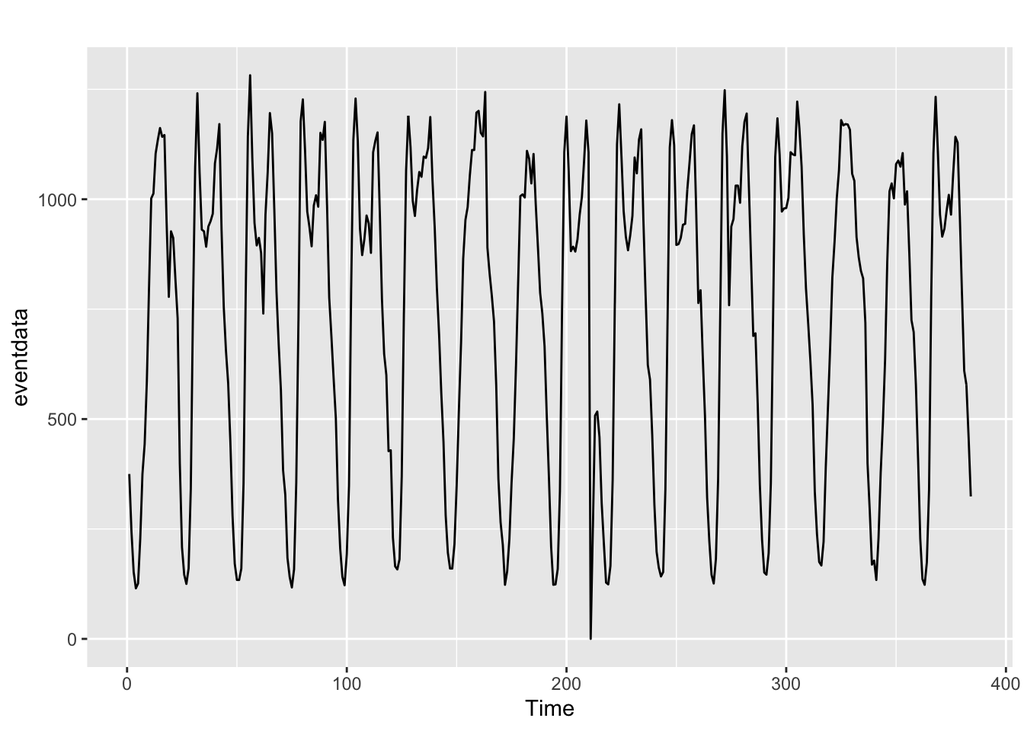

**Answer:** The data has constant variance and mean but shows signs of seasonality. There is not a trend.

# Question 2

Split the dataset into a training dataset which includes 6/16/2013 - 6/30/2013 samples and a test dataset which includes 7/1/2013 samples and plot the ACF and PACF.

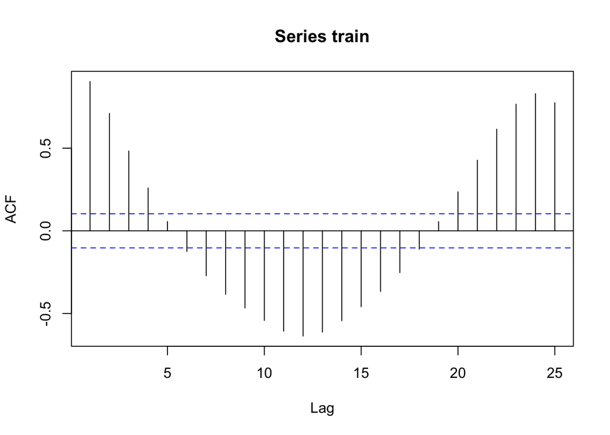

```r
# Train = 6/16/2013 - 6/30/2013
train <- as.ts(eventdata[1:360])

# Test = 7/1/2013
test <- as.ts(eventdata[360:length(eventdata)])


acf(train)
```

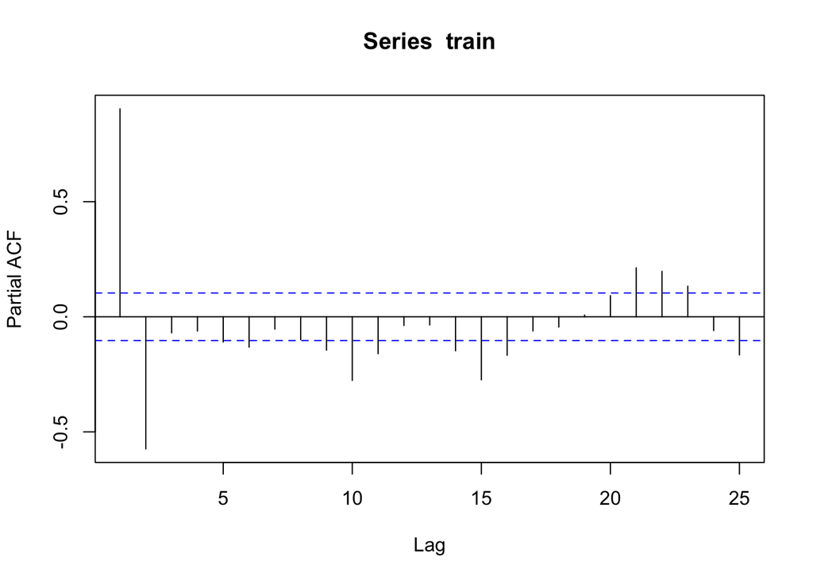

```r
pacf(train)
```

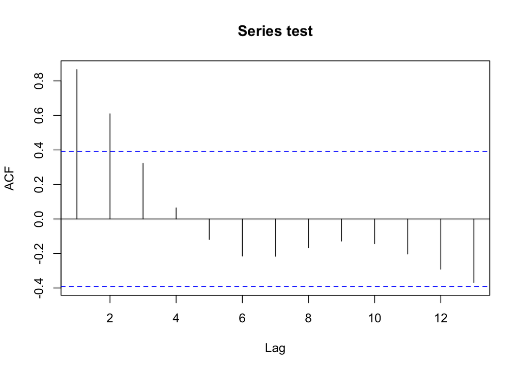

```r
acf(test)
```

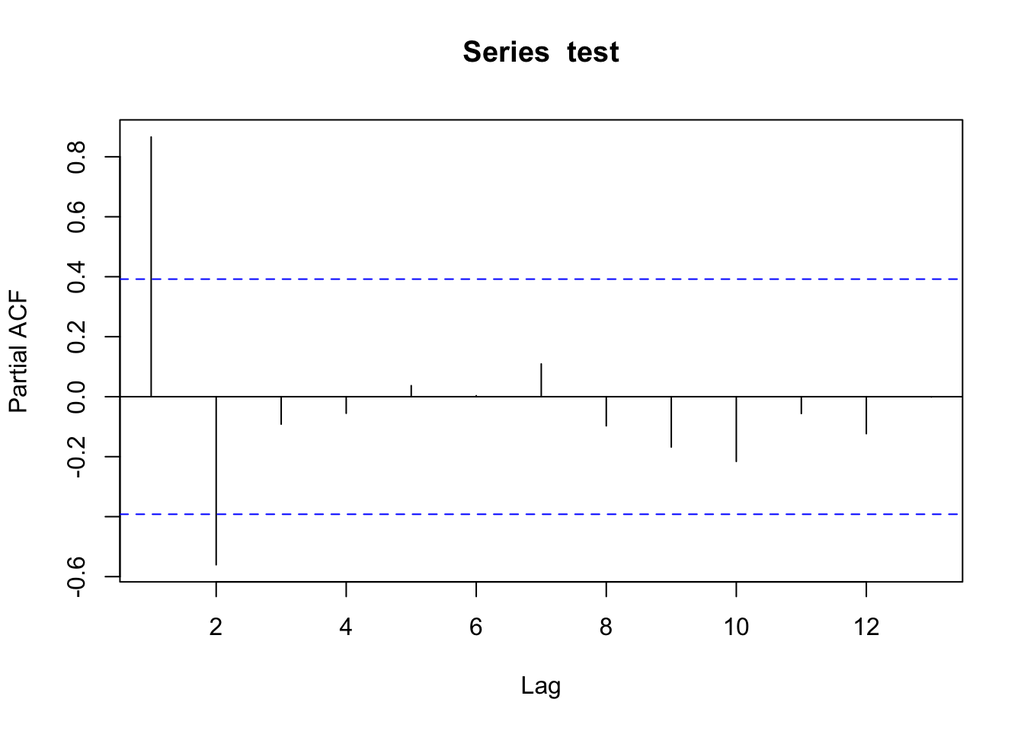

```r
pacf(test)
```

# Question 3

Build an 𝐴𝑅𝐼𝑀𝐴(𝑝, 𝑑, 𝑞) model using the training dataset and R auto.arima() function. Change the values of 𝑝 and 𝑞 and determine the best model using AICc and BIC values. Do AICc and BIC select the same model as the best model? For each derived model, review the residual plots for the residuals ACF and normality.

```r
# AIC
train_auto_aic <- auto.arima(train, seasonal=FALSE, trace=TRUE, ic = c("aicc"))
```

```
##
##  Fitting models using approximations to speed things up...
##
##  ARIMA(2,0,2) with non-zero mean : 4451.597
##  ARIMA(0,0,0) with non-zero mean : 5263.162
##  ARIMA(1,0,0) with non-zero mean : 4647.105
##  ARIMA(0,0,1) with non-zero mean : 4888.443
##  ARIMA(0,0,0) with zero mean     : 5858.997
##  ARIMA(1,0,2) with non-zero mean : 4516.808
##  ARIMA(2,0,1) with non-zero mean : 4495.758
##  ARIMA(3,0,2) with non-zero mean : 4453.461
##  ARIMA(2,0,3) with non-zero mean : 4450.838
##  ARIMA(1,0,3) with non-zero mean : 4510.357
##  ARIMA(3,0,3) with non-zero mean : 4453.807
##  ARIMA(2,0,4) with non-zero mean : 4450.888
##  ARIMA(1,0,4) with non-zero mean : 4512.163
##  ARIMA(3,0,4) with non-zero mean : 4455.568
##  ARIMA(2,0,3) with zero mean     : 4546.084
##
##  Now re-fitting the best model(s) without approximations...
##
##  ARIMA(2,0,3) with non-zero mean : 4455.881
##
##  Best model: ARIMA(2,0,3) with non-zero mean
```

```r
train_auto_aic
```

```
## Series: train
## ARIMA(2,0,3) with non-zero mean
##
## Coefficients:
##          ar1      ar2      ma1      ma2      ma3      mean
##       1.8088  -0.8853  -0.5348  -0.2671  -0.1157  746.3181
## s.e.  0.0288   0.0287   0.0600   0.0596   0.0654    6.8586
##
## sigma^2 = 13443:  log likelihood = -2220.78
## AIC=4455.56   AICc=4455.88   BIC=4482.77
```

```r
# BIC
train_auto_bic <- auto.arima(train, seasonal=FALSE, trace=TRUE, ic = c("bic"))
```

```
##
##  Fitting models using approximations to speed things up...
##
##  ARIMA(2,0,2) with non-zero mean : 4474.675
##  ARIMA(0,0,0) with non-zero mean : 5270.901
##  ARIMA(1,0,0) with non-zero mean : 4658.696
##  ARIMA(0,0,1) with non-zero mean : 4900.034
##  ARIMA(0,0,0) with zero mean     : 5862.871
##  ARIMA(1,0,2) with non-zero mean : 4536.069
##  ARIMA(2,0,1) with non-zero mean : 4515.019
##  ARIMA(3,0,2) with non-zero mean : 4480.346
##  ARIMA(2,0,3) with non-zero mean : 4477.723
##  ARIMA(1,0,1) with non-zero mean : 4558.698
##  ARIMA(1,0,3) with non-zero mean : 4533.435
##  ARIMA(3,0,1) with non-zero mean : 4477.636
##  ARIMA(3,0,3) with non-zero mean : 4484.486
##  ARIMA(2,0,2) with zero mean     : 4563.809
##
##  Now re-fitting the best model(s) without approximations...
##
##  ARIMA(2,0,2) with non-zero mean : 4479.834
##
##  Best model: ARIMA(2,0,2) with non-zero mean
```

```r
train_auto_bic
```

```
## Series: train
## ARIMA(2,0,2) with non-zero mean
##
## Coefficients:
##          ar1      ar2      ma1      ma2      mean
##       1.8308  -0.9072  -0.5916  -0.3254  746.3649
## s.e.  0.0229   0.0228   0.0488   0.0471    6.9120
##
## sigma^2 = 13514:  log likelihood = -2222.26
## AIC=4456.52   AICc=4456.76   BIC=4479.83
```

```r
# Look at best p, d, q values
arimaorder(train_auto_aic) #(2,0,3)
```

```
## p d q
## 2 0 3
```

```r
arimaorder(train_auto_bic) #(2,0,2)
```

```
## p d q
## 2 0 2
```

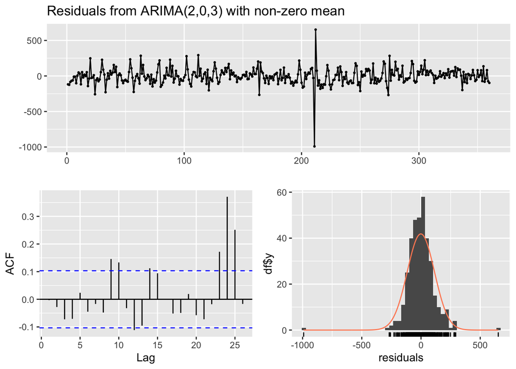

```
##
##  Ljung-Box test
##
## data:  Residuals from ARIMA(2,0,3) with non-zero mean
## Q* = 20.439, df = 5, p-value = 0.001033
##
## Model df: 5.   Total lags used: 10
```

```r
# Check Residuals
checkresiduals(train_auto_aic) #p-value < 0.01
```

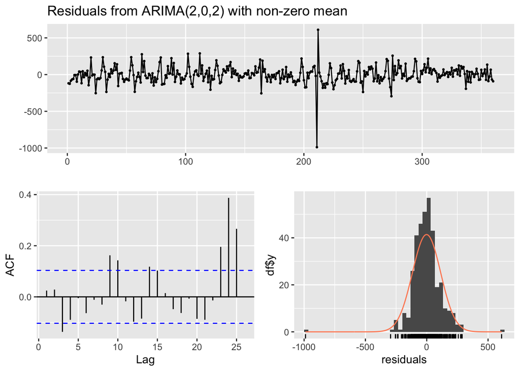

```
##
##  Ljung-Box test
##
## data:  Residuals from ARIMA(2,0,2) with non-zero mean
## Q* = 29.589, df = 6, p-value = 4.704e-05
##
## Model df: 4.   Total lags used: 10
```

```r
checkresiduals(train_auto_bic) #p-value < 0.01
```

```r
# Shapiro-Wilk Normality Test
shapiro.test(train_auto_aic$residuals) #p-value < 0.01
```

```
##
##  Shapiro-Wilk normality test
##
## data:  train_auto_aic$residuals
## W = 0.87428, p-value < 2.2e-16
```

```r
shapiro.test(train_auto_bic$residuals) #p-value < 0.01
```

```
##
##  Shapiro-Wilk normality test
##
## data:  train_auto_bic$residuals
## W = 0.88246, p-value = 5.754e-16
```

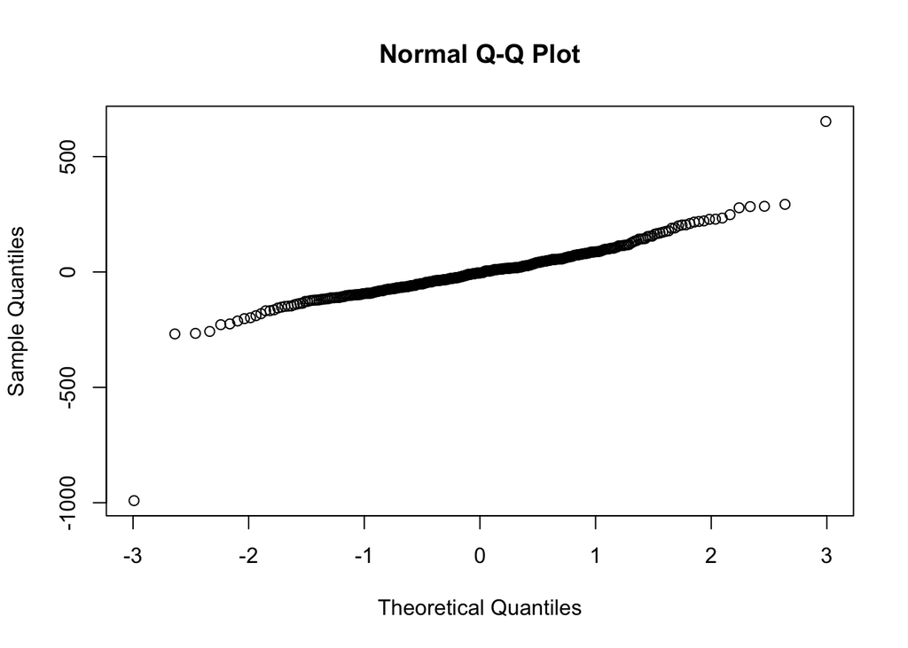

```r
# QQ Normality Plot
qqnorm(train_auto_aic$residuals)
```

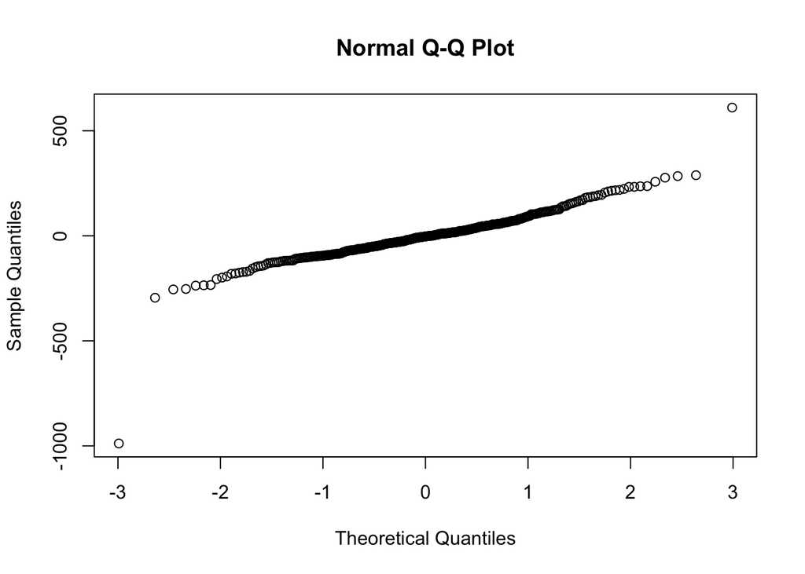

```r
qqnorm(train_auto_bic$residuals)
```

#### AIC/BIC:

- No, AICc and BIC select different models with this dataset. The best AICc model was ARIMA(2,0,3) whereas the best BIC model was ARIMA(2,0,2).

#### Residual Results

- The best performing AICc and BIC models had similar residual results. They both show autocorrelation at later lags, are right skewed in their distribution, and have some patterns in their plots. This indicates they do not resemble white noise. Their corresponding Ljung-Box test results both had small p-values indicated with Reject the Null Nypothesis and conclude autocorrelation exists.

#### Shapiro-Wilk Normality Test Results

- Both models show similar results for this test with small p-values. This indicates we Reject the Null Hypothesis and conclude the data deviates from a normal distribution.

#### Q-Q Plot Results

- These plots confirm the Shapiro-Wilk test results and indicate the data deviates from a normal distribution, especially when we examine quantiles -3 and 3.

# Question 4

Build a day of the week seasonal 𝐴𝑅𝐼𝑀𝐴(𝑝, 𝑑, 𝑞)(𝑃,𝑄,𝐷)𝑠 model using the training dataset and R auto.arima() function.

```r
weeklydata <- ts(alldata, frequency = 168) # There are 168 hours in 1 week

train_auto_week <- auto.arima(weeklydata,
                         seasonal = TRUE,
                         trace = TRUE)
```

```
##
##  Fitting models using approximations to speed things up...
##
##  ARIMA(2,1,2)(0,1,0)[168]                    : 1002.39
##  ARIMA(0,1,0)(0,1,0)[168]                    : 1060.517
##  ARIMA(1,1,0)(0,1,0)[168]                    : 1058.947
##  ARIMA(0,1,1)(0,1,0)[168]                    : 1043.249
##  ARIMA(1,1,2)(0,1,0)[168]                    : 996.5183
##  ARIMA(0,1,2)(0,1,0)[168]                    : 992.5297
##  ARIMA(0,1,3)(0,1,0)[168]                    : 993.9932
##  ARIMA(1,1,1)(0,1,0)[168]                    : 1004.073
##  ARIMA(1,1,3)(0,1,0)[168]                    : 998.3621
##
##  Now re-fitting the best model(s) without approximations...
##
##  ARIMA(0,1,2)(0,1,0)[168]                    : 2613.922
##
##  Best model: ARIMA(0,1,2)(0,1,0)[168]
```

```r
train_auto_week
```

```
## Series: weeklydata
## ARIMA(0,1,2)(0,1,0)[168]
##
## Coefficients:
##           ma1      ma2
##       -0.4553  -0.4966
## s.e.   0.0574   0.0570
##
## sigma^2 = 10455:  log likelihood = -1303.9
## AIC=2613.81   AICc=2613.92   BIC=2623.92
```

# Question 5

Use the 𝐴𝑅𝐼𝑀𝐴(𝑝, 𝑑, 𝑞)(𝑃, 𝑄, 𝐷)𝑠 model from Question 4 to forecast for July 1st (which is a Monday). Plot your result.

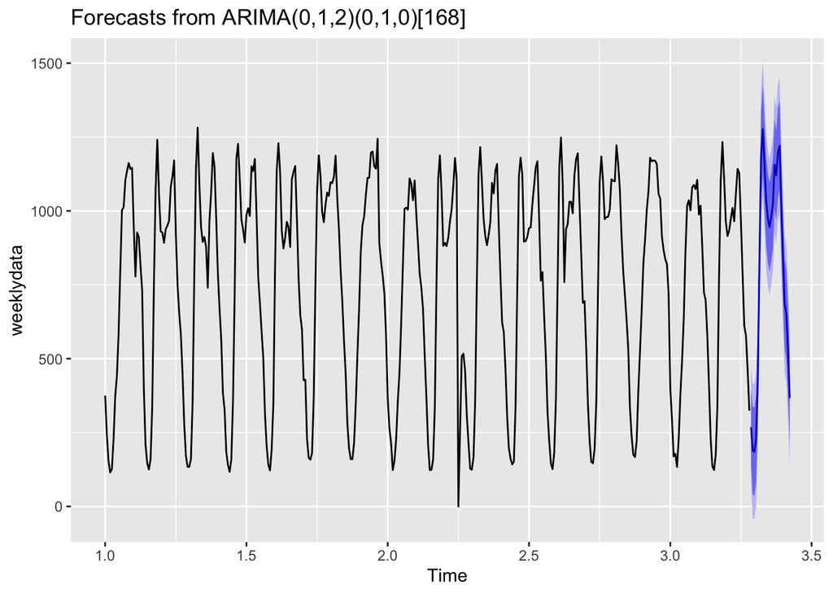

```r
week_forecast <- forecast(train_auto_week, h=24) # Forecast 24-hour period starting July 1st
autoplot(week_forecast)
```

# Question 6

Build a hour of the day seasonal 𝐴𝑅𝐼𝑀𝐴(𝑝, 𝑑, 𝑞)(𝑃,𝑄,𝐷)𝑠model using the training dataset and R auto.arima() function.

```r
hourly <- ts(alldata, frequency = 24) # 24 hours in day

hour_auto <- auto.arima(hourly,
                        seasonal = TRUE,
                        trace = TRUE)
```

```
##
##  Fitting models using approximations to speed things up...
##
##  ARIMA(2,0,2)(1,1,1)[24] with drift         : Inf
##  ARIMA(0,0,0)(0,1,0)[24] with drift         : 4516.521
##  ARIMA(1,0,0)(1,1,0)[24] with drift         : 4192.228
##  ARIMA(0,0,1)(0,1,1)[24] with drift         : 4267.391
##  ARIMA(0,0,0)(0,1,0)[24]                    : 4514.661
##  ARIMA(1,0,0)(0,1,0)[24] with drift         : 4237.725
##  ARIMA(1,0,0)(2,1,0)[24] with drift         : 4161.063
##  ARIMA(1,0,0)(2,1,1)[24] with drift         : Inf
##  ARIMA(1,0,0)(1,1,1)[24] with drift         : Inf
##  ARIMA(0,0,0)(2,1,0)[24] with drift         : 4432.798
##  ARIMA(2,0,0)(2,1,0)[24] with drift         : 4137.628
##  ARIMA(2,0,0)(1,1,0)[24] with drift         : 4177.616
##  ARIMA(2,0,0)(2,1,1)[24] with drift         : Inf
##  ARIMA(2,0,0)(1,1,1)[24] with drift         : Inf
##  ARIMA(3,0,0)(2,1,0)[24] with drift         : 4138.703
##  ARIMA(2,0,1)(2,1,0)[24] with drift         : 4135.681
##  ARIMA(2,0,1)(1,1,0)[24] with drift         : 4170.212
##  ARIMA(2,0,1)(2,1,1)[24] with drift         : Inf
##  ARIMA(2,0,1)(1,1,1)[24] with drift         : Inf
##  ARIMA(1,0,1)(2,1,0)[24] with drift         : 4142.062
##  ARIMA(3,0,1)(2,1,0)[24] with drift         : 4134.79
##  ARIMA(3,0,1)(1,1,0)[24] with drift         : 4169.16
##  ARIMA(3,0,1)(2,1,1)[24] with drift         : Inf
##  ARIMA(3,0,1)(1,1,1)[24] with drift         : Inf
##  ARIMA(4,0,1)(2,1,0)[24] with drift         : 4142.681
##  ARIMA(3,0,2)(2,1,0)[24] with drift         : 4136.867
##  ARIMA(2,0,2)(2,1,0)[24] with drift         : 4133.19
##  ARIMA(2,0,2)(1,1,0)[24] with drift         : 4168.693
##  ARIMA(2,0,2)(2,1,1)[24] with drift         : Inf
##  ARIMA(1,0,2)(2,1,0)[24] with drift         : 4140.359
##  ARIMA(2,0,3)(2,1,0)[24] with drift         : 4142.689
##  ARIMA(1,0,3)(2,1,0)[24] with drift         : 4139.954
##  ARIMA(3,0,3)(2,1,0)[24] with drift         : Inf
##  ARIMA(2,0,2)(2,1,0)[24]                    : 4131.105
##  ARIMA(2,0,2)(1,1,0)[24]                    : 4166.613
##  ARIMA(2,0,2)(2,1,1)[24]                    : Inf
##  ARIMA(2,0,2)(1,1,1)[24]                    : Inf
##  ARIMA(1,0,2)(2,1,0)[24]                    : 4138.282
##  ARIMA(2,0,1)(2,1,0)[24]                    : 4133.61
##  ARIMA(3,0,2)(2,1,0)[24]                    : 4134.769
##  ARIMA(2,0,3)(2,1,0)[24]                    : 4140.593
##  ARIMA(1,0,1)(2,1,0)[24]                    : 4139.997
##  ARIMA(1,0,3)(2,1,0)[24]                    : 4137.865
##  ARIMA(3,0,1)(2,1,0)[24]                    : 4132.705
##  ARIMA(3,0,3)(2,1,0)[24]                    : Inf
##
##  Now re-fitting the best model(s) without approximations...
##
##  ARIMA(2,0,2)(2,1,0)[24]                    : 4387.414
##
##  Best model: ARIMA(2,0,2)(2,1,0)[24]
```

```r
hour_auto
```

```
## Series: hourly
## ARIMA(2,0,2)(2,1,0)[24]
##
## Coefficients:
##          ar1      ar2      ma1      ma2     sar1     sar2
##       1.6133  -0.7045  -0.6731  -0.1803  -0.4401  -0.3603
## s.e.  0.0552   0.0475   0.0723   0.0636   0.0542   0.0509
##
## sigma^2 = 10904:  log likelihood = -2186.55
## AIC=4387.1   AICc=4387.41   BIC=4414.3
```

# Question 7

Use the 𝐴𝑅𝐼𝑀𝐴(𝑝, 𝑑, 𝑞)(𝑃, 𝑄, 𝐷)𝑠 model from Question 6 to forecast for July 1st (which is a Monday). Plot your result.

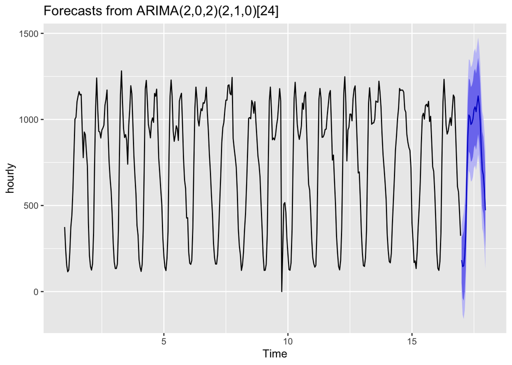

```r
hour_forecast <- forecast(hour_auto, h=24) # Forecast 24-hour period starting July 1st
autoplot(hour_forecast)
```

# Question 8

Compare the forecast of the models from Questions 5 and 7 for July 1 8:00, 9:00, 17:00 and 18:00, which model is better (Questions 4 or 6)?

```r
times <- c("2013-07-01 08:00:00", #1,233
           "2013-07-01 09:00:00", #1,110
           "2013-07-01 17:00:00", #1,142
           "2013-07-01 18:00:00") #1,129

# For July, get the indexes that match the times
time_indexes <- which(as.character(time_index)[360:384] %in% times) # 9, 10, 18, 19
test[time_indexes]
```

```
## [1] 1233 1110 1142 1129
```

```r
# Use the same indexes for the Actual test set and forecasted to compare
week_error <- test[time_indexes] - week_forecast$mean[time_indexes] #Actual - Pred
hour_error <- test[time_indexes] - hour_forecast$mean[time_indexes]

# Calculate sum of squared errors
week_sse <- sum(week_error^2)
hour_sse <- sum(hour_error^2)

# Compare: is the week forecast error higher?
week_sse > hour_sse # FALSE
```

```
## [1] FALSE
```

```r
paste("Weekly Forecast Model SSE =", round(week_sse,2))
```

```
## [1] "Weekly Forecast Model SSE = 30876.98"
```

```r
paste("Hour Forecast Model SSE =", round(hour_sse,2))
```

```
## [1] "Hour Forecast Model SSE = 89982.1"
```

**Answer:** The Weekly model from Question #4 is better. This model had an SSE of 30,876 and the Hourly model from Question #6 had an SSE of 89,982.